# R4DS_2E_strings

Martin

2026-01-19

## Transform - Creating a string

1. Create strings that contain the following values:
- He said “That’s amazing!”
- \\\

```r
string1 <- "He said \"That's amazing!\""
str_view(string1)
```

```
## [1] │ He said "That's amazing!"
```

```r
string2 <- "\\a\\b\\c\\d"
str_view(string2)
```

```
## [1] │ \a\b\c\d
```

```r
string3 <- "\\\\\\\\\\\\"
str_view(string3)
```

```
## [1] │ \\\\\\
```

2. Create the string in your R session and print it. What happens to the special “0a0”? How does str_view() display it? Can you do a little googling to figure out what this special character is?

```r
x <- "This\u00a0is\u00a0tricky"
str_view(x)
```

```
## [1] │ This{\u00a0}is{\u00a0}tricky
```

```r
# Seems to just put the literal unicode but in curly brackets. After googling it appears to be the special invisible character (much like a spacebar stroke but not the exact same)
```

## Transform - Creating many strings from data

1. Compare and contrast the results of paste0() with str_c() for the following inputs:

```r
#str_c("hi ", NA) # [1] NA
#str_c(letters[1:2], letters[1:3]) # Creates an error as it can't recycle a size 2 vector with a size 3 one
#paste0("hi ", NA) # paste0 doesn't follow the rules about missing values which can be seen as a negative
#paste0(letters[1:2], letters[1:3]) # It matches aa, bb, and then the first size 2 vector is "recycled" and a matches with c to produce ac
```

2. What’s the difference between paste() and paste0()? How can you recreate the equivalent of paste() with str_c()?

```r
paste0("hi ", "world")
```

```
## [1] "hi world"
```

```r
paste("hi ", "world") # paste automatically adds a space between each string, paste0 doesn't
```

```
## [1] "hi  world"
```

```r
# str_c has a separator argument. For paste to be equivalent to str_c we need to do `sep = " "`. This still doesn't work exactly the same is we have a missing value and I'm not sure how to remedy this
str_c("hi ", "world", sep = " ")
```

```
## [1] "hi  world"
```

```r
paste("hi ", "world")
```

```
## [1] "hi  world"
```

3. Convert the following expressions from str_c() to str_glue() or vice versa:

```r
food = "chocolate"
price = "£5"
str_c("The price of ", food, " is ", price)
```

```
## [1] "The price of chocolate is £5"
```

```r
str_glue("The price of {food} is {price}")
```

```
## The price of chocolate is £5
```

```r
age = 23
country = "England"
str_glue("I'm {age} years old and live in {country}")
```

```
## I'm 23 years old and live in England
```

```r
str_c("I'm ", age, " years old and live in ", country)
```

```
## [1] "I'm 23 years old and live in England"
```

```r
title = "Lord of the Rings"
str_c("\\section{", title, "}")
```

```
## [1] "\\section{Lord of the Rings}"
```

```r
str_glue("\\\\section{{{title}}}")
```

```
## \\section{Lord of the Rings}
```

```r
# Remember that with glue you adding special characters we double up that special character.
```

## Transform - Letters

1. When computing the distribution of the length of babynames, why did we use wt = n?

```r
# babynames has its owns column called n which tells us how many people in this dataset have the name Mary for example. Therefore, we have to use `wt = n` to add up all these values to get an accurate depiction of how many people have name lengths of 2, 3, etc.
babynames
```

```
## # A tibble: 1,924,665 × 5
##     year sex   name          n   prop
##    <dbl> <chr> <chr>     <int>  <dbl>
##  1  1880 F     Mary       7065 0.0724
##  2  1880 F     Anna       2604 0.0267
##  3  1880 F     Emma       2003 0.0205
##  4  1880 F     Elizabeth  1939 0.0199
##  5  1880 F     Minnie     1746 0.0179
##  6  1880 F     Margaret   1578 0.0162
##  7  1880 F     Ida        1472 0.0151
##  8  1880 F     Alice      1414 0.0145
##  9  1880 F     Bertha     1320 0.0135
## 10  1880 F     Sarah      1288 0.0132
## # ℹ 1,924,655 more rows
```

```r
babynames |>
  count(length = str_length(name))
```

```
## # A tibble: 14 × 2
##    length      n
##     <int>  <int>
##  1      2   4660
##  2      3  41274
##  3      4 177838
##  4      5 404291
##  5      6 546519
##  6      7 424360
##  7      8 213803
##  8      9  78946
##  9     10  23437
## 10     11   6461
## 11     12   1610
## 12     13    946
## 13     14    390
## 14     15    130
```

```r
# Note how the n column is specified in the wt argument so its not relevant in computing n in the above

babynames |>
  count(length = str_length(name), wt = n)
```

```
## # A tibble: 14 × 2
##    length        n
##     <int>    <int>
##  1      2   338150
##  2      3  8589596
##  3      4 48506739
##  4      5 87011607
##  5      6 90749404
##  6      7 72120767
##  7      8 25404066
##  8      9 11926551
##  9     10  1306159
## 10     11  2135827
## 11     12    16295
## 12     13    10845
## 13     14     3681
## 14     15      830
```

2. Use str_length() and str_sub() to extract the middle letter from each baby name. What will you do if the string has an even number of characters?

```r
# I'm choosing to include the middle two letters if the string has an even number of characters
example <- c("Martin", "Lukic", "1", "")
str_sub(example,
        if_else(str_length(example) %% 2 == 0,
           str_length(example) / 2,
           ceiling(str_length(example) / 2)),
        if_else(str_length(example) %% 2 == 0,
           (str_length(example) / 2) + 1,
           ceiling(str_length(example) / 2))
        )
```

```
## [1] "rt" "k"  "1"  ""
```

3. Are there any major trends in the length of babynames over time? What about the popularity of first and last letters?

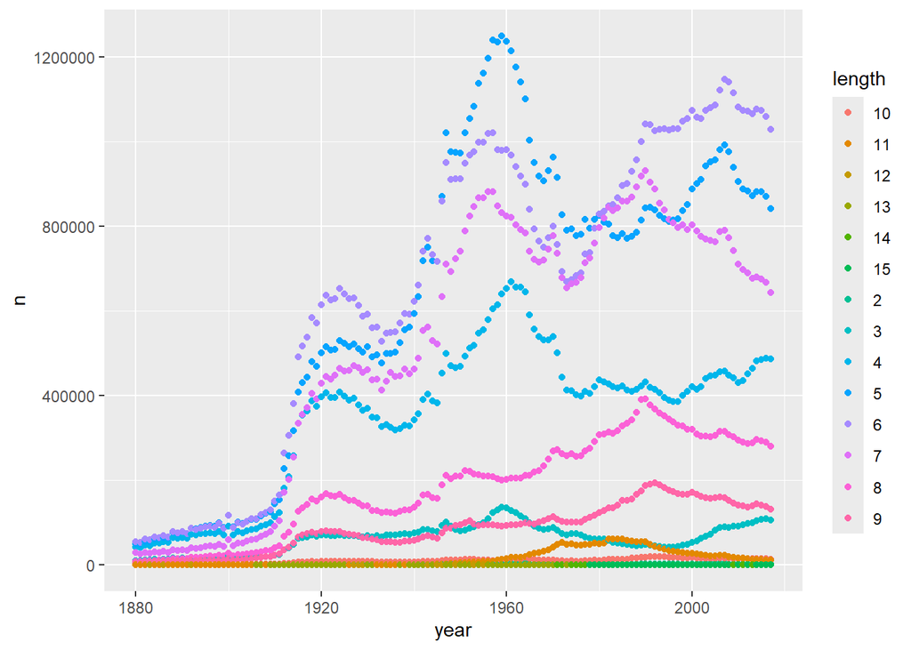

```r
babynames |>
  group_by(year) |>
  count(length = str_length(name), wt = n) |>
  mutate(length = as.character(length)) |>
  ggplot(aes(year, n, colour = length)) +
  geom_point()
```

```r
# We see that very large names stay relatively the same throughout the years. Interestingly between the years 1880-1910 there is a much more "even" spread in terms of the counts of lengths of babynames. Then after this point, names of length 5,6 and 7 shoot up, then temper and reduce abit, then shoot back in post 1940, again drop off post 1960 then are steadily rising once more. We should probably look at this graph but with proportions of babynames instead as the count may be obfuscating the larger length babynames.
```